# Comparison of polygenic risk, predicted transcriptomic and observed trans

# Germline risk

## Germline risk: Predicted transcriptomic score (PTRS)

This is the code to generate the predicted transcriptomic risk score and assess its ability to prognosticate overall survival and progression free survival among breast cancer patients.

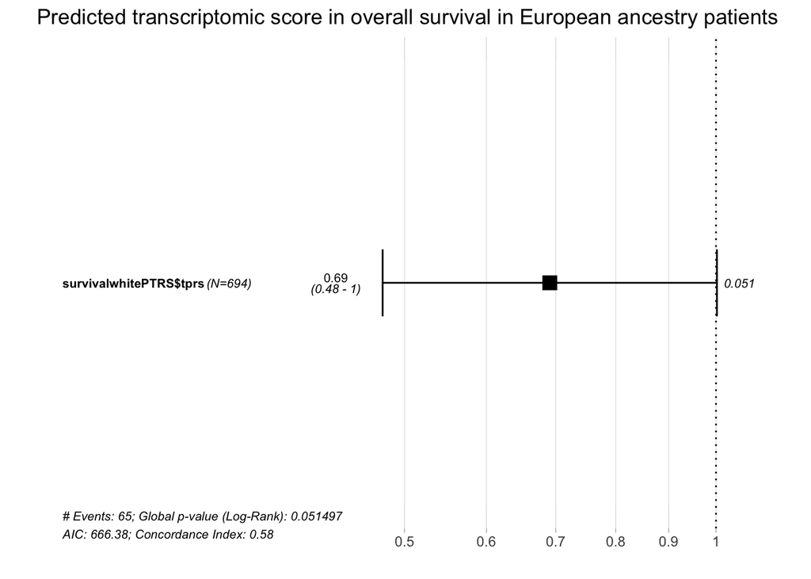

We see an association between PTRS (predicted transcriptomic) score and overall survival. This score incorporates the germline in both genes associated with risk (by weights) and in terms of the predicted transcriptome.

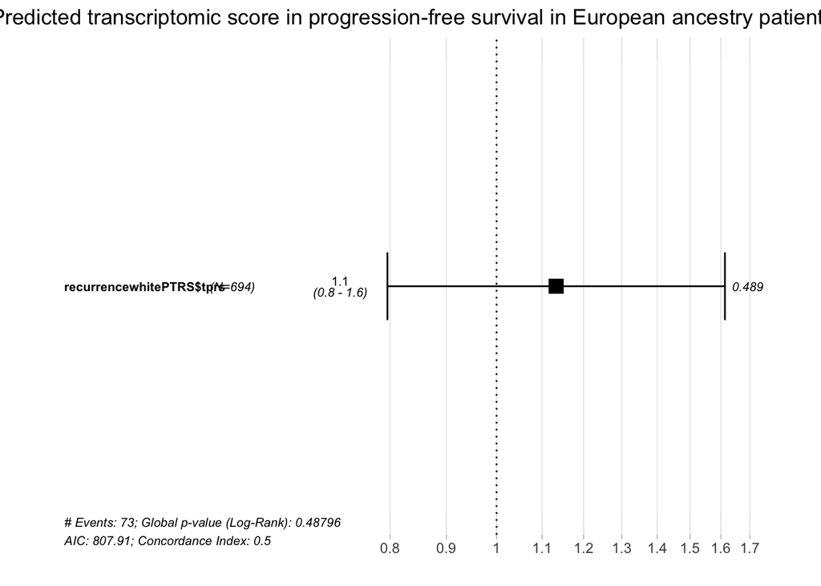

We see no association between PTRS score and PFS.

## Germline risk: Observed transcriptomic score (OTRS)

This is the code to generate the observed transcriptomic risk score and assess its ability to prognosticate overall survival and progression free survival among breast cancer patients.

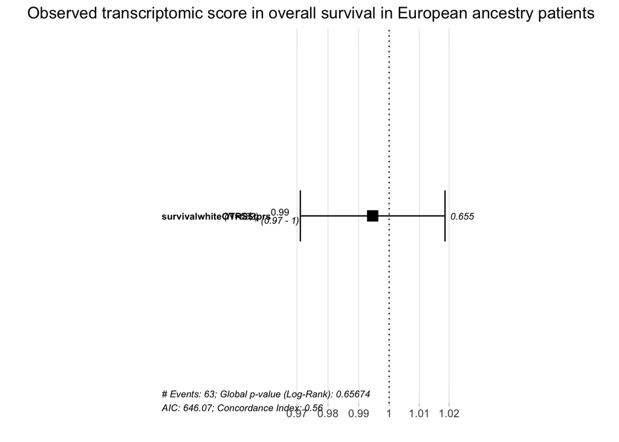

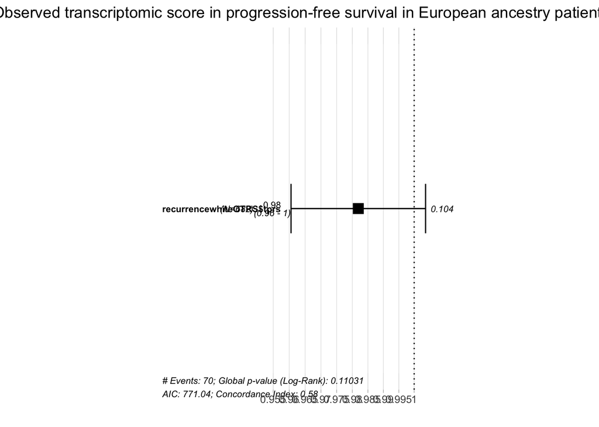

There is a minimal signal that is not clinically significant and does not reach statistical significance, but this is the next closest signal of score performance.

# Survival

## Survival-related variants: Predicted transcriptomic score (PTRS)

This is the code to generate the predicted transcriptomic risk score (using survival GWAS as a weight) and assess its ability to prognosticate overall survival and progression free survival among breast cancer patients.

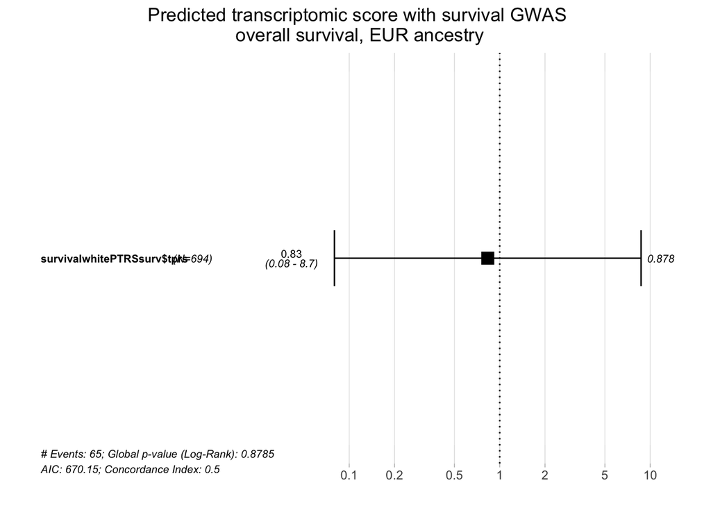

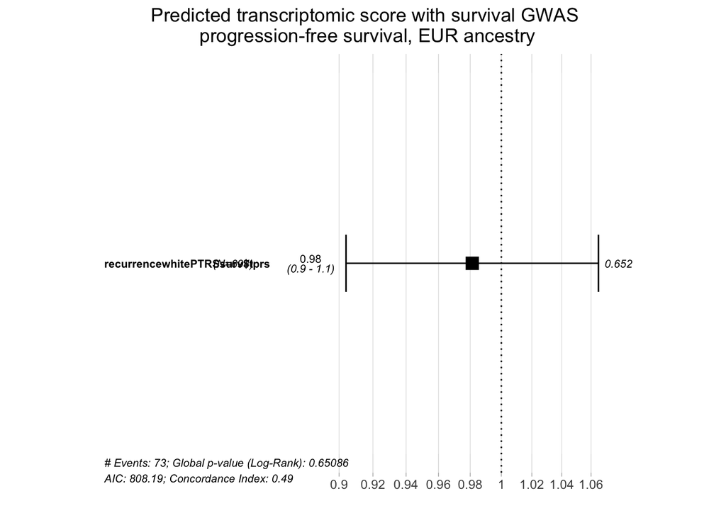

## Survival-related variants: Observed transcriptomic score (OTRS)

This is the code to generate the observed transcriptomic risk score (using survival GWAS as a weight) and assess its ability to prognosticate overall survival and progression free survival among breast cancer patients.

[figure not shown]

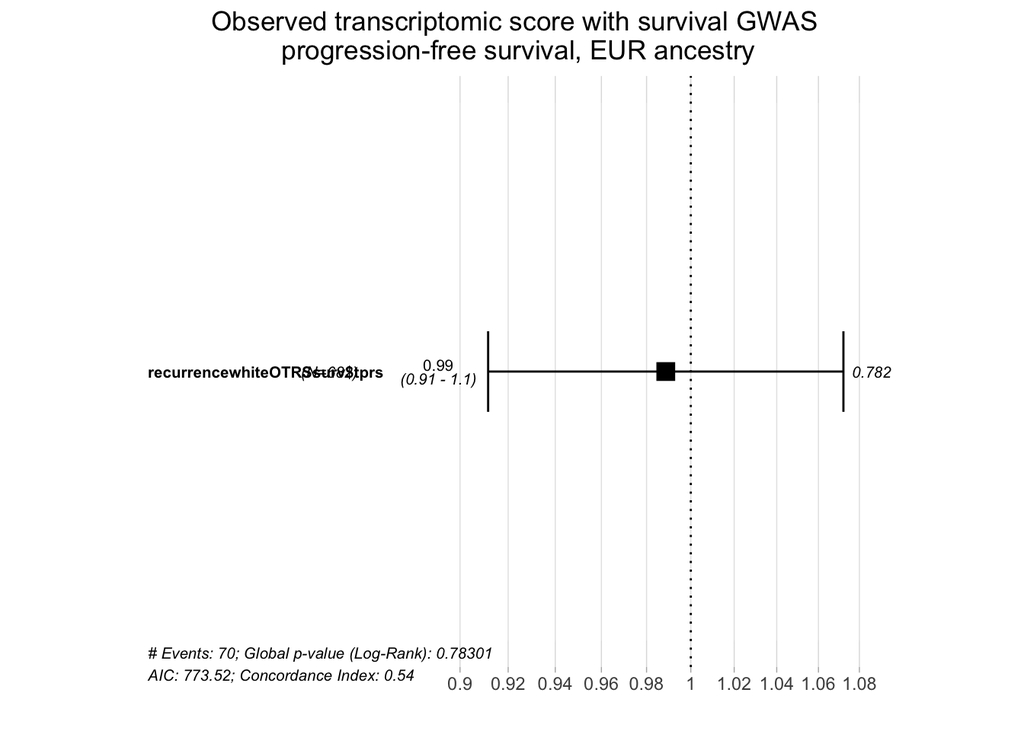

When survival is used as the weighting factor, there is no longer any association between any score and survival outcomes.

This is the code to generate the predicted transcriptomic risk score (using subtype-specific GWAS results and calculated for patients within that subtype) and assess its ability to prognosticate overall survival and progression free survival among breast cancer patients.

# Subtype-specific variants

## LumA/ Predicted (PTRS)

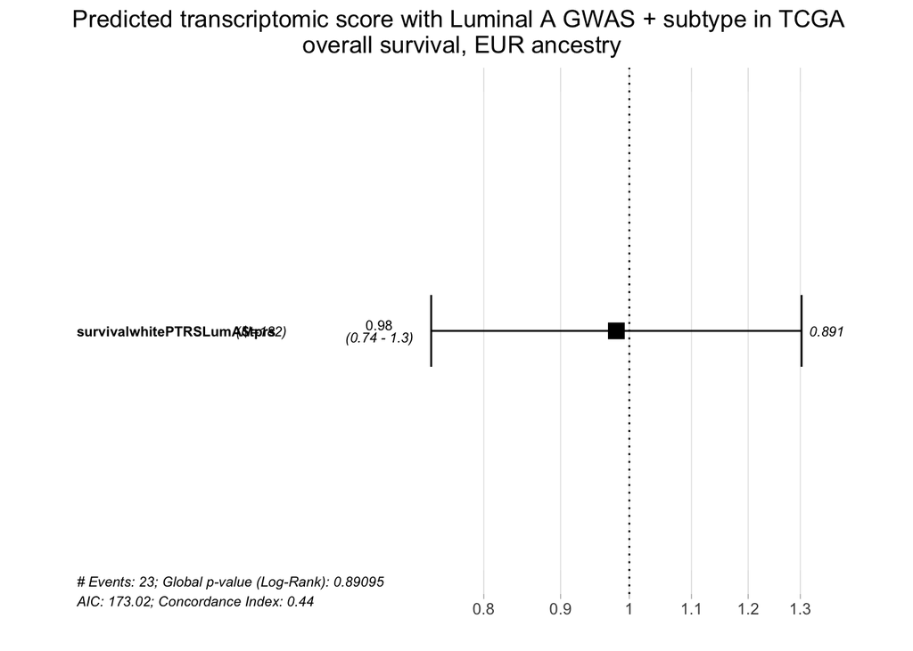

## LumB/ Predicted (PTRS)

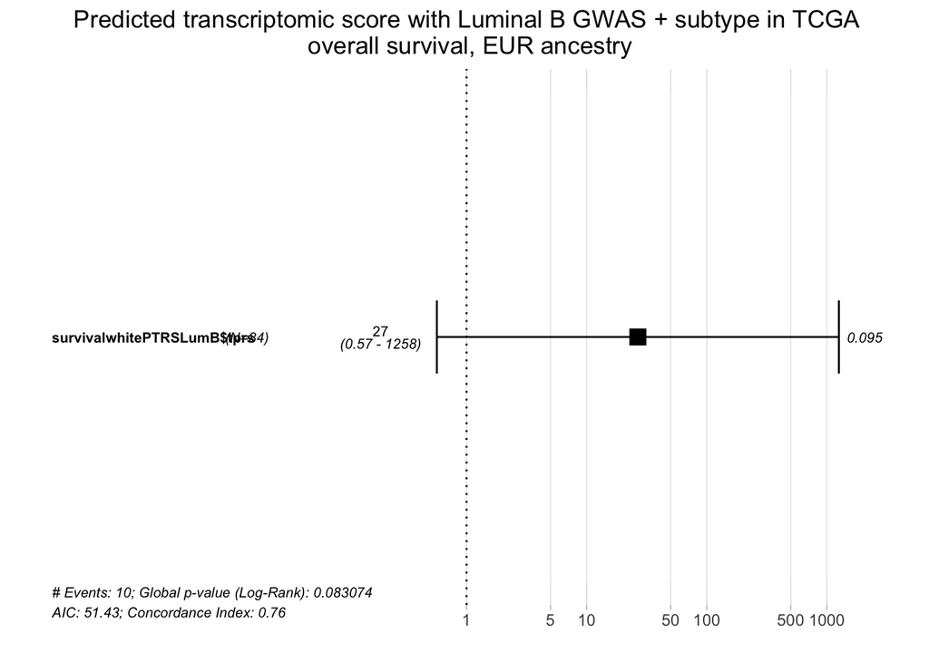

## TNBC/ Predicted (PTRS)

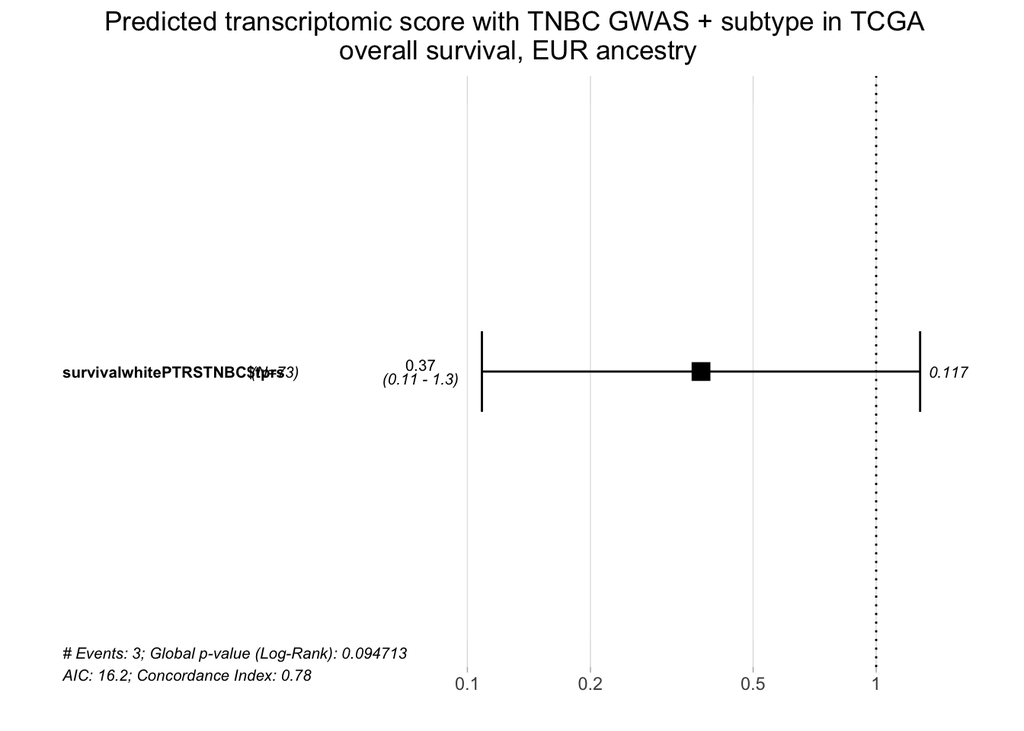

## HER2/ Predicted (PTRS)

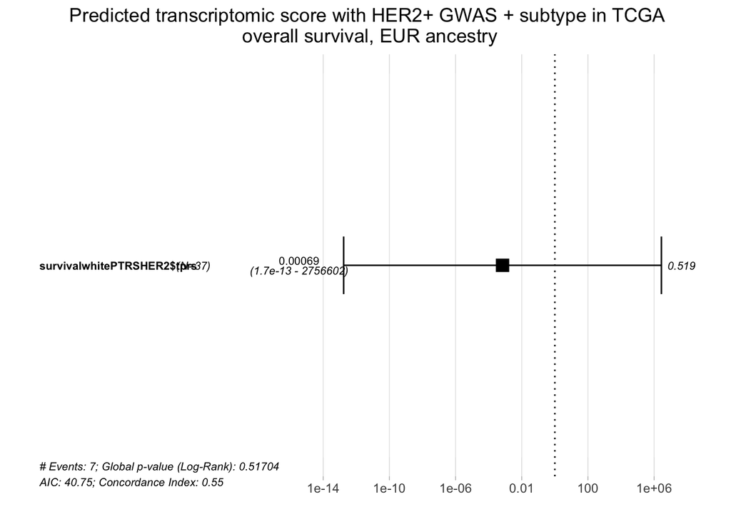

## Combined subtype-specific contribution (PTRS)

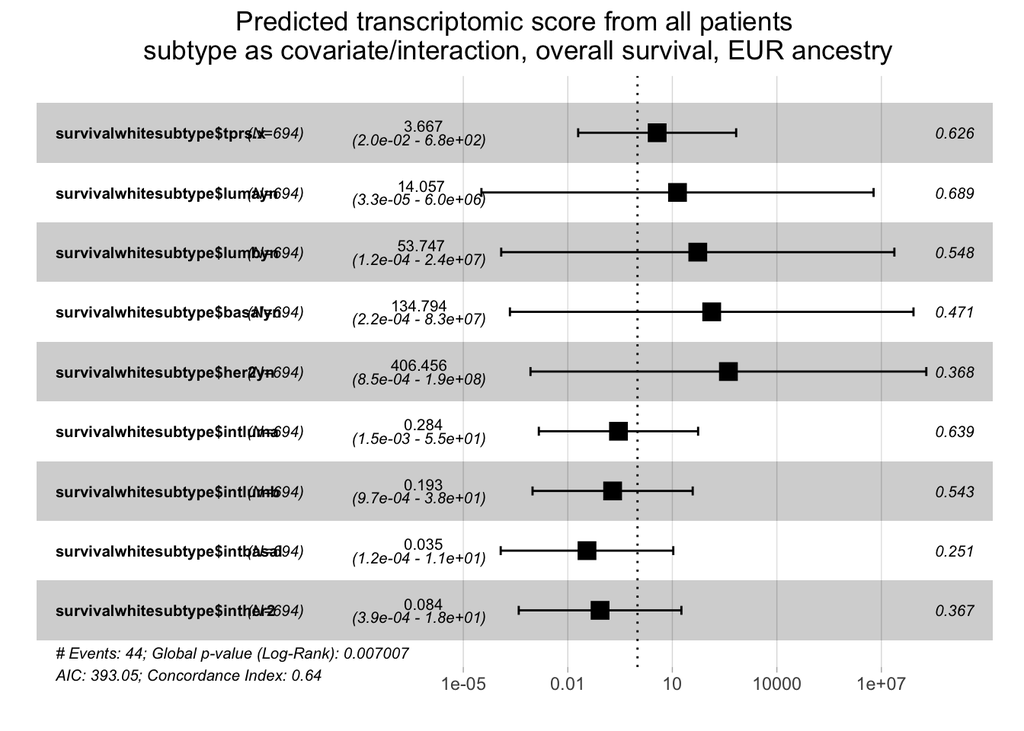

No specific subtype (which are drived from existing RNA subtype methods) drove the score performance (although luminal B had the strongest effect). RNA-based subtype resulted in decreased efficacy of score performance.

# Combined scores + clinical data

## Clinical: Overall survival

|  | beta | HR (95% CI for HR) | wald.test | p.value |
| --- | --- | --- | --- | --- |
| age | 0.04 | 1 (1-1.1) | 15 | 1e-04 |
| AJCCN | 0.55 | 1.7 (1.3-2.2) | 17 | 3.3e-05 |
| AJCCT | 0.38 | 1.5 (1.1-2) | 6.3 | 0.012 |
| AJCCM | 1.6 | 5.1 (2.5-10) | 20 | 6e-06 |
| hr | 0.61 | 1.8 (0.82-4.1) | 2.2 | 0.14 |
| her2 | -0.33 | 0.72 (0.26-2) | 0.39 | 0.53 |
| score | -0.048 | 0.95 (0.63-1.4) | 0.05 | 0.82 |
| PTRS | -0.37 | 0.69 (0.47-1) | 3.8 | 0.053 |
| OTRS | -0.0054 | 0.99 (0.97-1) | 0.2 | 0.66 |

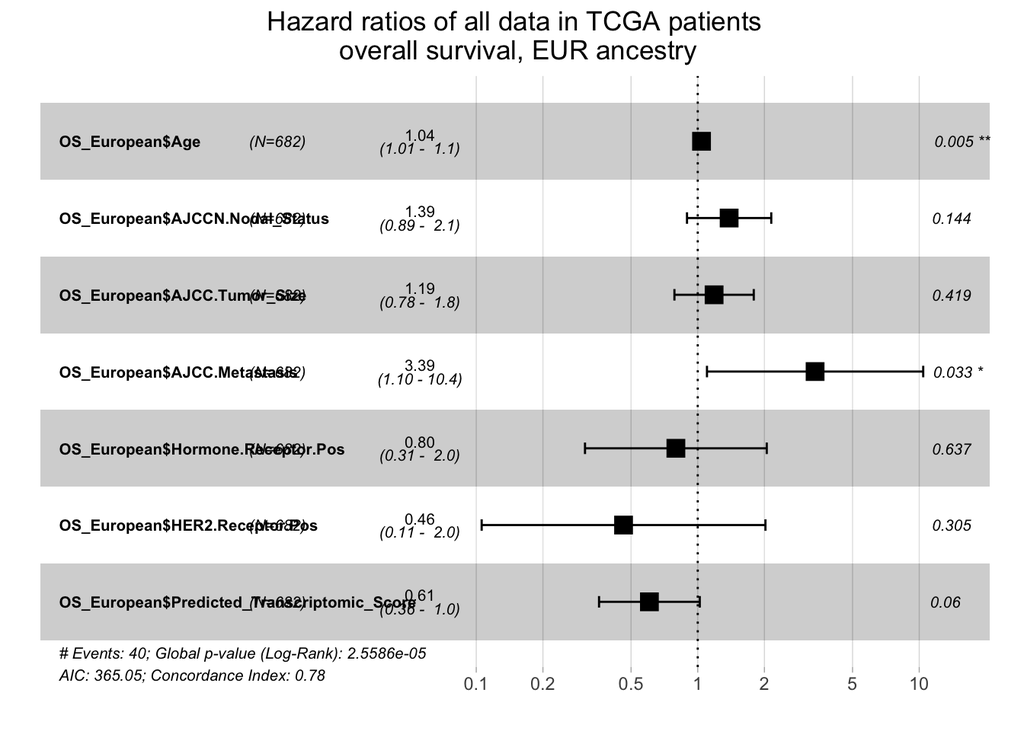

## Clinical: Progression-free survival

|  | beta | HR (95% CI for HR) | wald.test | p.value |
| --- | --- | --- | --- | --- |
| age | 0.0087 | 1 (0.99-1) | 0.75 | 0.39 |
| AJCCN | 0.62 | 1.9 (1.4-2.4) | 23 | 1.3e-06 |
| AJCCT | 0.5 | 1.6 (1.2-2.2) | 12 | 0.00046 |
| AJCCM | 1.5 | 4.3 (2.1-8.7) | 16 | 5.2e-05 |
| hr | 0.0049 | 1 (0.52-1.9) | 0 | 0.99 |
| her2 | -0.069 | 0.93 (0.37-2.4) | 0.02 | 0.89 |
| pam50luma | -0.24 | 0.79 (0.42-1.5) | 0.53 | 0.47 |
| pam50lumb | 0.19 | 1.2 (0.5-2.9) | 0.18 | 0.67 |
| pam50her2 | 1.1 | 3 (1.2-7.6) | 5.8 | 0.016 |
| pam50basal | -0.25 | 0.78 (0.36-1.7) | 0.39 | 0.53 |

[output cut: 3 more lines]

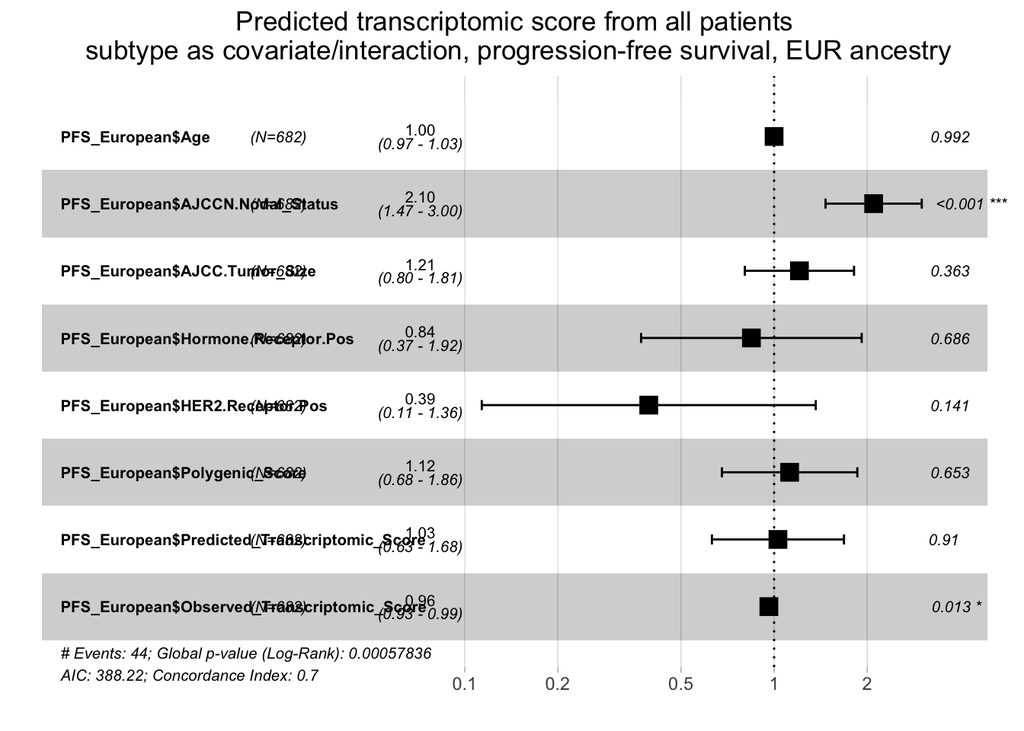

When combined with clinical data, the score performance of PTRS in overall survival remained persistent, offering an interesting signal to study further. The performance of OTRS in PFS was actually improved with clinical data (more consistent with real-world data), but this was no longer significant with incorporation of PAM50 data, suggesting that the latter encompasses the same information that the former does and the germline does not add specific information in that context.

# Clustering and feature selection

# Alternate models: OS: BGLM-Cox / BGLM Weibull

# Alternate models: PFS: MSR-RF / Boosted Trees

# Alternate models: COXNNET with no selection